# Oyster Data Explorer

20 June 2015

## Overview

The pitch for this app is that it allows a user to explore and interogate data for their activity on [Transport for London](https://tfl.gov.uk/) - the London transport network.

It's also more than just exploration. The aim of this app is that it will allow users to better understand their journey patterns, how long they spend in the network, and what time(s) are best for them to travel.

The proof-of-concept developed so far presents interective exploration of station visits, journey times accross London and a commute optimiser to help users find their best travel arrangements.

The app that this presentation serves can be found [here](https://jleach.shinyapps.io/shiny)

## Journey Times

Living in London means a lot of time travelling - but just how much? A simple histogram of journey times lets a user understand their usage:

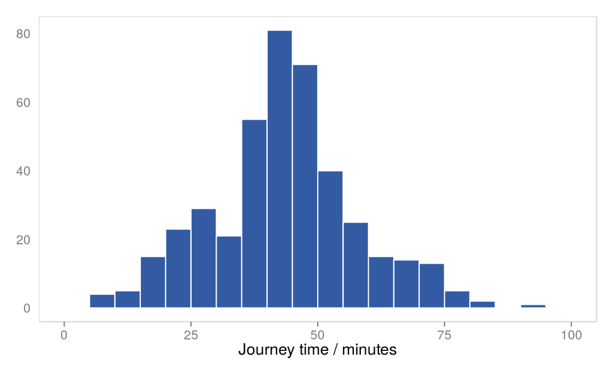

## Commute Optimiser

A quick custom visualisation of journey duration vs. start time lets a user find the best time to set off in the London rush hour:

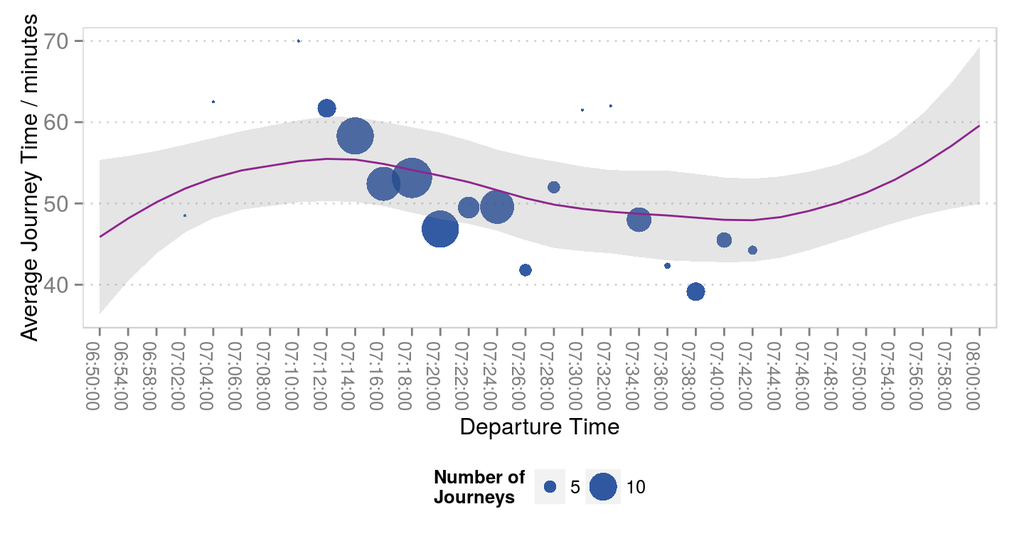

```r
CommutePlot(combined, startMorning, endMorning, 2)
```

## Why a Shiny App?

Static data analyses like those shown in this presentation are fine for one-offs. But with Shiny they become interactive charts that update as more data is gathered.

Furthermore, the interactivity of Shiny means it is:

- Bespoke - a user will be able to submit their own data and select their own summaries.
- Insightful - allowing a user to "play" with their own data lets them ask their own questions of it.

The flexibility of Shiny means that new features can be requested and added easily, keeping the app fresh and relevant to users. This proof-of-concept shows the how the ease and simplicity can help a user understand their data, engage with it, and begin asking questions to help them optimise their travel in a hectic city.